# Case Study 1

Olivia Leeson

10/28/2016

# Introduction

The purpose of this paper is to explore the GDPs and income groups of the countries of the world. We have data that has been pulled from the worldbank online databank for the countries that have records of reported GDP among other data. We have two raw csv files: one containing the GDP information and another containing other important economic statistics such as income group. The worldbank data are updated retroactively to reflect the most recent updates on the 2015 statistics.

Our goal is to answer the following questions:

1. How many of the IDs match from the merged data sets?
2. Which country ranks #13 in the ascending list of GDPs (which country has the 13th lowest GDP)?
3. What are the average GDP rankings for the “High income: OECD” and “High income: nonOECD” groups?
4. Plot the GDP for all of the countries.
5. How many countries are Lower middle income but among the 38 nations with highest GDP?

# The Data

#### Important Note: *Please set your working directory to the directory containing the downloaded files from Github*

We run a makefile that includes the code to gather, clean, and merge the raw data files.

```r
source("makefile.txt")
summary(both, n=3)
```

```
##      C_Code          ID                    Country.x     GDP_Mills
##  ABW    :  1   178    :  2   Afghanistan        :  1   Min.   :      40
##  AFG    :  1   1      :  1   Albania            :  1   1st Qu.:    6972
##  AGO    :  1   10     :  1   Algeria            :  1   Median :   28242
##  ALB    :  1   100    :  1   Angola             :  1   Mean   :  379597
##  ARE    :  1   101    :  1   Antigua and Barbuda:  1   3rd Qu.:  205789
##  ARG    :  1   102    :  1   Argentina          :  1   Max.   :16244600
##  (Other):183   (Other):182   (Other)            :183
##                   Country.y                 Income.Group
##  Antigua and Barbuda   :  1                       : 0
##  Arab Republic of Egypt:  1   High income: nonOECD:23
##  Argentine Republic    :  1   High income: OECD   :30
##  Aruba                 :  1   Low income          :37
##  Barbados              :  1   Lower middle income :54
##  Belize                :  1   Upper middle income :45
##  (Other)               :183
##                         Region
##  Europe & Central Asia     :50
##  Sub-Saharan Africa        :46
##  Latin America & Caribbean :35
##  East Asia & Pacific       :29
##  Middle East & North Africa:18
##  South Asia                : 8
##  (Other)                   : 3
```

Our remaining dataset includes 189 countries with data on the the GDP in Millions and the Income Group of those countries.

# Analysis

## 1

After we merge our two data sets, how many of the IDs match?

```r
length(both$C_Code)
```

```
## [1] 189
```

189 Country Codes match.

## 2

Which country ranks #13 in the ascending list of GDPs?

```r
both$Rank <- as.numeric(gsub("[^[:digit:]]","", both$ID))
both$Country.y[both$Rank == 13]
```

```
## [1] Kingdom of Spain
## 234 Levels: American Samoa Antigua and Barbuda ... World
```

## 3

What is the average GDP rankings for the High Income: OECD countries?

```r
highoecd <- (both$Rank[both$Income.Group=="High income: OECD"])
sumhighoecd <- sum(highoecd)
counthighoecd <- length(highoecd)
avghighoecd <- sumhighoecd/counthighoecd
avghighoecd
```

```
## [1] 32.96667
```

The average GDP rankings for the High Income: OECD countries is 32.9, or about 33.

What is the average GDP rankings for the High Income: nonOECD countries?

```r
highnon <- (both$Rank[both$Income.Group=="High income: nonOECD"])
sumhighnon <- sum(highnon)
counthighnon<- length(highnon)
avghighnon<- sumhighnon/counthighnon
avghighnon
```

```
## [1] 91.91304
```

The average GDP rankings for the High Income: nonOECD countries is 91.9, or about 92.

The average rankings of the High Income countries shows that the countries in OECD have, on average, higher GDPs thank those countries with high incomes but are not part of OECD.

## 4

Scatter Plot of GDP for all Countries

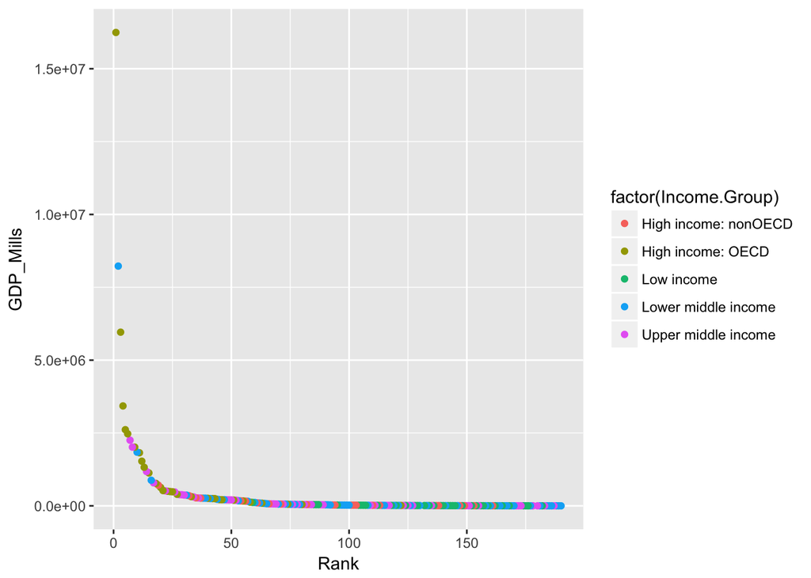

```r
library(ggplot2)
p <- ggplot(both, aes(Rank,GDP_Mills))
P <- p + geom_point()
p <- p + geom_point(aes(colour=factor(Income.Group)))
p
```

The United States clearly has the highest GDP by far. The scatter plot is hard to read because the U.S. is an outlier for this data. We can see that there is a huge GDP disparity between the top 5 countries and the rest.

```r
tail(both$C_Code, n=5)
```

```
## [1] FRA DEU JPN CHN USA
## 229 Levels:  ABW ADO AFG AGO ALB ARE ARG ARM ASM ATG AUS AUT AZE ... ZWE
```

The top 5 countries in GDP are USA, China, Japan, Germany, and France

## 5

GDP Rankings versus Income Group

```r
both$qnt <- cut(both$Rank, breaks=quantile(both$Rank, probs=seq(0,1,0.2)), labels=1:5, include.lowest=TRUE)
otable <- table(both$Income.Group, both$qnt)
otable
```

```
##
##                         1  2  3  4  5
##                         0  0  0  0  0
##   High income: nonOECD  4  5  8  4  2
##   High income: OECD    18 10  1  1  0
##   Low income            0  1  9 16 11
##   Lower middle income   5 13 11  9 16
##   Upper middle income  11  9  8  8  9
```

The numbers of the quartiles are 1-5. 1 being in the top 20% and 5 being in the bottom 20%. We can tell from the table that for the Lower-middle income group, 5 countries are in the top 20% in GDP, 13 in the 20-40%, 11 in the 40-60%, 9 in the 60-80%, and 16 countries are in the bottom 20% in GDP.

There are 5 countries that are lower-middle income but among the top 38 nations with the highest GDP.

# Conclusion